# Risk Factor Analysis

## Outcome Variable

**Outcome Variable:** dead0plus

## Predictor Variables

**Intervention Variable:** ever_swasted024

**Adjustment Set:**

- sex
- arm
- brthmon
- vagbrth
- hhwealth_quart
- W_mage
- W_mhtcm
- W_mwtkg
- W_mbmi
- W_meducyrs
- W_feducyrs
- W_nrooms
- W_parity
- impsan
- safeh20
- delta_vagbrth
- delta_hhwealth_quart
- delta_W_mage
- delta_W_mhtcm
- delta_W_mwtkg
- delta_W_mbmi
- delta_W_meducyrs
- delta_W_feducyrs
- delta_W_nrooms
- delta_W_parity
- delta_impsan
- delta_safeh20

## Stratifying Variables

The analysis was stratified on these variable(s):

- studyid
- country

## Data Summary

| studyid | country | ever_swasted024 | dead0plus | n_cell | n | outcome_variable |
| --- | --- | --- | --- | --- | --- | --- |
| Burkina Faso Zn | BURKINA FASO | 0 | 0 | 6821 | 7166 | dead0plus |
| Burkina Faso Zn | BURKINA FASO | 0 | 1 | 43 | 7166 | dead0plus |
| Burkina Faso Zn | BURKINA FASO | 1 | 0 | 297 | 7166 | dead0plus |
| Burkina Faso Zn | BURKINA FASO | 1 | 1 | 5 | 7166 | dead0plus |
| EE | PAKISTAN | 0 | 0 | 298 | 380 | dead0plus |
| EE | PAKISTAN | 0 | 1 | 2 | 380 | dead0plus |
| EE | PAKISTAN | 1 | 0 | 78 | 380 | dead0plus |
| EE | PAKISTAN | 1 | 1 | 2 | 380 | dead0plus |
| GMS-Nepal | NEPAL | 0 | 0 | 503 | 686 | dead0plus |
| GMS-Nepal | NEPAL | 0 | 1 | 6 | 686 | dead0plus |
| GMS-Nepal | NEPAL | 1 | 0 | 176 | 686 | dead0plus |
| GMS-Nepal | NEPAL | 1 | 1 | 1 | 686 | dead0plus |
| iLiNS-DOSE | MALAWI | 0 | 0 | 1784 | 1931 | dead0plus |
| iLiNS-DOSE | MALAWI | 0 | 1 | 124 | 1931 | dead0plus |
| iLiNS-DOSE | MALAWI | 1 | 0 | 19 | 1931 | dead0plus |
| iLiNS-DOSE | MALAWI | 1 | 1 | 4 | 1931 | dead0plus |
| iLiNS-DYAD-M | MALAWI | 0 | 0 | 1135 | 1201 | dead0plus |
| iLiNS-DYAD-M | MALAWI | 0 | 1 | 38 | 1201 | dead0plus |
| iLiNS-DYAD-M | MALAWI | 1 | 0 | 24 | 1201 | dead0plus |
| iLiNS-DYAD-M | MALAWI | 1 | 1 | 4 | 1201 | dead0plus |
| JiVitA-3 | BANGLADESH | 0 | 0 | 24773 | 26956 | dead0plus |
| JiVitA-3 | BANGLADESH | 0 | 1 | 538 | 26956 | dead0plus |
| JiVitA-3 | BANGLADESH | 1 | 0 | 1580 | 26956 | dead0plus |
| JiVitA-3 | BANGLADESH | 1 | 1 | 65 | 26956 | dead0plus |
| JiVitA-4 | BANGLADESH | 0 | 0 | 5059 | 5443 | dead0plus |
| JiVitA-4 | BANGLADESH | 0 | 1 | 41 | 5443 | dead0plus |
| JiVitA-4 | BANGLADESH | 1 | 0 | 334 | 5443 | dead0plus |
| JiVitA-4 | BANGLADESH | 1 | 1 | 9 | 5443 | dead0plus |
| Keneba | GAMBIA | 0 | 0 | 2323 | 2920 | dead0plus |
| Keneba | GAMBIA | 0 | 1 | 71 | 2920 | dead0plus |
| Keneba | GAMBIA | 1 | 0 | 500 | 2920 | dead0plus |
| Keneba | GAMBIA | 1 | 1 | 26 | 2920 | dead0plus |
| MAL-ED | BANGLADESH | 0 | 0 | 240 | 263 | dead0plus |
| MAL-ED | BANGLADESH | 0 | 1 | 2 | 263 | dead0plus |
| MAL-ED | BANGLADESH | 1 | 0 | 21 | 263 | dead0plus |
| MAL-ED | BANGLADESH | 1 | 1 | 0 | 263 | dead0plus |
| MAL-ED | INDIA | 0 | 0 | 223 | 251 | dead0plus |
| MAL-ED | INDIA | 0 | 1 | 2 | 251 | dead0plus |
| MAL-ED | INDIA | 1 | 0 | 26 | 251 | dead0plus |
| MAL-ED | INDIA | 1 | 1 | 0 | 251 | dead0plus |
| MAL-ED | PERU | 0 | 0 | 296 | 302 | dead0plus |
| MAL-ED | PERU | 0 | 1 | 2 | 302 | dead0plus |
| MAL-ED | PERU | 1 | 0 | 4 | 302 | dead0plus |
| MAL-ED | PERU | 1 | 1 | 0 | 302 | dead0plus |
| MAL-ED | SOUTH AFRICA | 0 | 0 | 296 | 312 | dead0plus |
| MAL-ED | SOUTH AFRICA | 0 | 1 | 0 | 312 | dead0plus |
| MAL-ED | SOUTH AFRICA | 1 | 0 | 16 | 312 | dead0plus |
| MAL-ED | SOUTH AFRICA | 1 | 1 | 0 | 312 | dead0plus |
| MAL-ED | TANZANIA, UNITED REPUBLIC OF | 0 | 0 | 249 | 261 | dead0plus |
| MAL-ED | TANZANIA, UNITED REPUBLIC OF | 0 | 1 | 3 | 261 | dead0plus |
| MAL-ED | TANZANIA, UNITED REPUBLIC OF | 1 | 0 | 9 | 261 | dead0plus |
| MAL-ED | TANZANIA, UNITED REPUBLIC OF | 1 | 1 | 0 | 261 | dead0plus |
| PROVIDE | BANGLADESH | 0 | 0 | 653 | 700 | dead0plus |
| PROVIDE | BANGLADESH | 0 | 1 | 5 | 700 | dead0plus |
| PROVIDE | BANGLADESH | 1 | 0 | 42 | 700 | dead0plus |
| PROVIDE | BANGLADESH | 1 | 1 | 0 | 700 | dead0plus |
| SAS-CompFeed | INDIA | 0 | 0 | 1267 | 1513 | dead0plus |
| SAS-CompFeed | INDIA | 0 | 1 | 23 | 1513 | dead0plus |
| SAS-CompFeed | INDIA | 1 | 0 | 209 | 1513 | dead0plus |
| SAS-CompFeed | INDIA | 1 | 1 | 14 | 1513 | dead0plus |
| SAS-FoodSuppl | INDIA | 0 | 0 | 344 | 418 | dead0plus |
| SAS-FoodSuppl | INDIA | 0 | 1 | 3 | 418 | dead0plus |
| SAS-FoodSuppl | INDIA | 1 | 0 | 68 | 418 | dead0plus |
| SAS-FoodSuppl | INDIA | 1 | 1 | 3 | 418 | dead0plus |
| TanzaniaChild2 | TANZANIA, UNITED REPUBLIC OF | 0 | 0 | 2237 | 2396 | dead0plus |
| TanzaniaChild2 | TANZANIA, UNITED REPUBLIC OF | 0 | 1 | 1 | 2396 | dead0plus |
| TanzaniaChild2 | TANZANIA, UNITED REPUBLIC OF | 1 | 0 | 158 | 2396 | dead0plus |
| TanzaniaChild2 | TANZANIA, UNITED REPUBLIC OF | 1 | 1 | 0 | 2396 | dead0plus |
| VITAMIN-A | INDIA | 0 | 0 | 3461 | 3904 | dead0plus |
| VITAMIN-A | INDIA | 0 | 1 | 55 | 3904 | dead0plus |
| VITAMIN-A | INDIA | 1 | 0 | 368 | 3904 | dead0plus |
| VITAMIN-A | INDIA | 1 | 1 | 20 | 3904 | dead0plus |
| ZVITAMBO | ZIMBABWE | 0 | 0 | 11783 | 13946 | dead0plus |
| ZVITAMBO | ZIMBABWE | 0 | 1 | 877 | 13946 | dead0plus |
| ZVITAMBO | ZIMBABWE | 1 | 0 | 1101 | 13946 | dead0plus |
| ZVITAMBO | ZIMBABWE | 1 | 1 | 185 | 13946 | dead0plus |

The following strata were considered:

- studyid: Burkina Faso Zn, country: BURKINA FASO
- studyid: EE, country: PAKISTAN
- studyid: GMS-Nepal, country: NEPAL
- studyid: iLiNS-DOSE, country: MALAWI
- studyid: iLiNS-DYAD-M, country: MALAWI
- studyid: JiVitA-3, country: BANGLADESH
- studyid: JiVitA-4, country: BANGLADESH
- studyid: Keneba, country: GAMBIA
- studyid: MAL-ED, country: BANGLADESH
- studyid: MAL-ED, country: INDIA
- studyid: MAL-ED, country: PERU
- studyid: MAL-ED, country: SOUTH AFRICA
- studyid: MAL-ED, country: TANZANIA, UNITED REPUBLIC OF
- studyid: PROVIDE, country: BANGLADESH
- studyid: SAS-CompFeed, country: INDIA
- studyid: SAS-FoodSuppl, country: INDIA
- studyid: TanzaniaChild2, country: TANZANIA, UNITED REPUBLIC OF
- studyid: VITAMIN-A, country: INDIA
- studyid: ZVITAMBO, country: ZIMBABWE

### Dropped Strata

Some strata were dropped due to rare outcomes:

- studyid: EE, country: PAKISTAN
- studyid: GMS-Nepal, country: NEPAL
- studyid: iLiNS-DOSE, country: MALAWI
- studyid: iLiNS-DYAD-M, country: MALAWI
- studyid: MAL-ED, country: BANGLADESH
- studyid: MAL-ED, country: INDIA
- studyid: MAL-ED, country: PERU
- studyid: MAL-ED, country: SOUTH AFRICA
- studyid: MAL-ED, country: TANZANIA, UNITED REPUBLIC OF
- studyid: PROVIDE, country: BANGLADESH
- studyid: SAS-FoodSuppl, country: INDIA
- studyid: TanzaniaChild2, country: TANZANIA, UNITED REPUBLIC OF

## Methods Detail

We’re interested in the causal parameters $E[Y_a]$ for all values of $a \in \mathcal{A}$. These parameters represent the mean outcome if, possibly contrary to fact, we intervened to set all units to have $A=a$. Under the randomization and positivity assumptions, these are identified by the statistical parameters $\psi_a=E_W[E_{Y|A,W}(Y|A=a,W)]$. In addition, we’re interested in the mean of $Y$, $E[Y]$ under no intervention (the observed mean). We will estimate these parameters by using SuperLearner to fit the relevant likelihood factors – $E_{Y|A,W}(Y|A=a,W)$ and $p(A=a|W)$, and then updating our likelihood fit using a joint TMLE.

For unadjusted analyses ($W=\{\}$), initial likelihoods were estimated using Lrnr_glm to estimate the simple $E(Y|A)$ and Lrnr_mean to estimate $p(A)$. For adjusted analyses, a small library containing Lrnr_glmnet, Lrnr_xgboost, and Lrnr_mean was used.

Having estimated these parameters, we will then use the delta method to estimate relative risks and attributable risks relative to a prespecified baseline level of $A$.

# Results Detail

## Results Plots

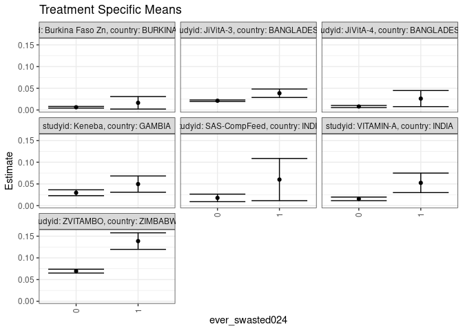

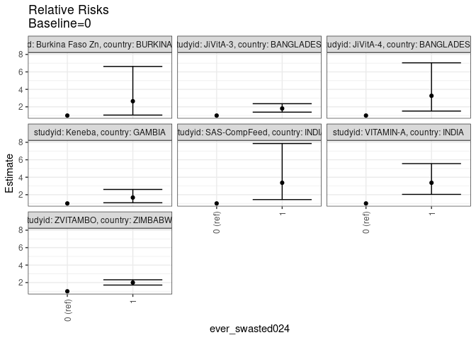

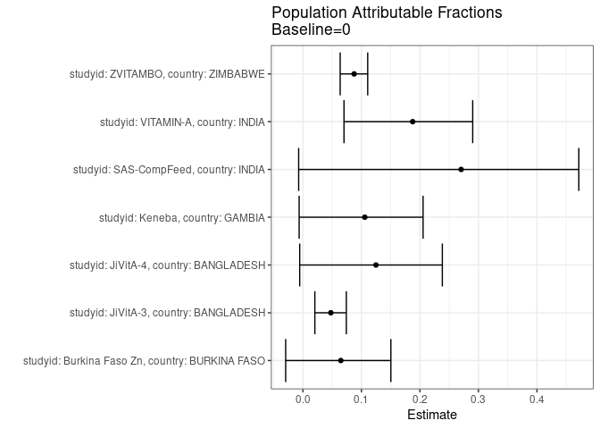

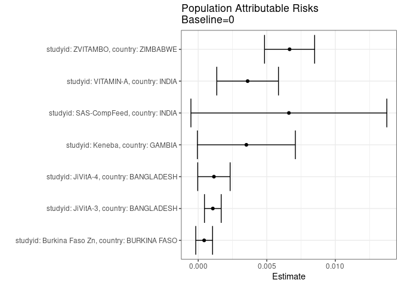

## Results Table

### Parameter: TSM

| studyid | country | intervention_level | baseline_level | estimate | ci_lower | ci_upper |
| --- | --- | --- | --- | --- | --- | --- |
| Burkina Faso Zn | BURKINA FASO | 0 | NA | 0.0062646 | 0.0043979 | 0.0081313 |
| Burkina Faso Zn | BURKINA FASO | 1 | NA | 0.0165563 | 0.0021640 | 0.0309486 |
| JiVitA-3 | BANGLADESH | 0 | NA | 0.0213032 | 0.0195045 | 0.0231018 |
| JiVitA-3 | BANGLADESH | 1 | NA | 0.0385684 | 0.0288410 | 0.0482959 |
| JiVitA-4 | BANGLADESH | 0 | NA | 0.0080392 | 0.0055796 | 0.0104989 |
| JiVitA-4 | BANGLADESH | 1 | NA | 0.0262391 | 0.0077322 | 0.0447460 |
| Keneba | GAMBIA | 0 | NA | 0.0297066 | 0.0228952 | 0.0365180 |
| Keneba | GAMBIA | 1 | NA | 0.0496655 | 0.0309469 | 0.0683842 |
| SAS-CompFeed | INDIA | 0 | NA | 0.0178411 | 0.0092080 | 0.0264741 |
| SAS-CompFeed | INDIA | 1 | NA | 0.0600498 | 0.0114534 | 0.1086463 |
| VITAMIN-A | INDIA | 0 | NA | 0.0156064 | 0.0115064 | 0.0197065 |
| VITAMIN-A | INDIA | 1 | NA | 0.0525040 | 0.0300211 | 0.0749870 |
| ZVITAMBO | ZIMBABWE | 0 | NA | 0.0694861 | 0.0650649 | 0.0739072 |
| ZVITAMBO | ZIMBABWE | 1 | NA | 0.1386556 | 0.1195994 | 0.1577119 |

### Parameter: E(Y)

| studyid | country | intervention_level | baseline_level | estimate | ci_lower | ci_upper |
| --- | --- | --- | --- | --- | --- | --- |
| Burkina Faso Zn | BURKINA FASO | NA | NA | 0.0066983 | 0.0048096 | 0.0085870 |
| JiVitA-3 | BANGLADESH | NA | NA | 0.0223698 | 0.0205726 | 0.0241670 |
| JiVitA-4 | BANGLADESH | NA | NA | 0.0091861 | 0.0065991 | 0.0117731 |
| Keneba | GAMBIA | NA | NA | 0.0332192 | 0.0267180 | 0.0397203 |
| SAS-CompFeed | INDIA | NA | NA | 0.0244547 | 0.0133604 | 0.0355490 |
| VITAMIN-A | INDIA | NA | NA | 0.0192111 | 0.0149047 | 0.0235174 |
| ZVITAMBO | ZIMBABWE | NA | NA | 0.0761509 | 0.0717486 | 0.0805531 |

### Parameter: RR

| studyid | country | intervention_level | baseline_level | estimate | ci_lower | ci_upper |
| --- | --- | --- | --- | --- | --- | --- |
| Burkina Faso Zn | BURKINA FASO | 0 | 0 | 1.000000 | 1.000000 | 1.000000 |
| Burkina Faso Zn | BURKINA FASO | 1 | 0 | 2.642846 | 1.054333 | 6.624698 |
| JiVitA-3 | BANGLADESH | 0 | 0 | 1.000000 | 1.000000 | 1.000000 |
| JiVitA-3 | BANGLADESH | 1 | 0 | 1.810455 | 1.389790 | 2.358448 |
| JiVitA-4 | BANGLADESH | 0 | 0 | 1.000000 | 1.000000 | 1.000000 |
| JiVitA-4 | BANGLADESH | 1 | 0 | 3.263884 | 1.513196 | 7.040024 |
| Keneba | GAMBIA | 0 | 0 | 1.000000 | 1.000000 | 1.000000 |
| Keneba | GAMBIA | 1 | 0 | 1.671869 | 1.075459 | 2.599027 |
| SAS-CompFeed | INDIA | 0 | 0 | 1.000000 | 1.000000 | 1.000000 |
| SAS-CompFeed | INDIA | 1 | 0 | 3.365823 | 1.440841 | 7.862603 |
| VITAMIN-A | INDIA | 0 | 0 | 1.000000 | 1.000000 | 1.000000 |
| VITAMIN-A | INDIA | 1 | 0 | 3.364260 | 2.035648 | 5.560020 |
| ZVITAMBO | ZIMBABWE | 0 | 0 | 1.000000 | 1.000000 | 1.000000 |
| ZVITAMBO | ZIMBABWE | 1 | 0 | 1.995446 | 1.715775 | 2.320703 |

### Parameter: PAR

| studyid | country | intervention_level | baseline_level | estimate | ci_lower | ci_upper |
| --- | --- | --- | --- | --- | --- | --- |
| Burkina Faso Zn | BURKINA FASO | 0 | NA | 0.0004337 | -0.0001798 | 0.0010472 |
| JiVitA-3 | BANGLADESH | 0 | NA | 0.0010666 | 0.0004567 | 0.0016765 |
| JiVitA-4 | BANGLADESH | 0 | NA | 0.0011469 | -0.0000345 | 0.0023283 |
| Keneba | GAMBIA | 0 | NA | 0.0035126 | -0.0000604 | 0.0070855 |
| SAS-CompFeed | INDIA | 0 | NA | 0.0066137 | -0.0005312 | 0.0137585 |
| VITAMIN-A | INDIA | 0 | NA | 0.0036046 | 0.0013552 | 0.0058541 |
| ZVITAMBO | ZIMBABWE | 0 | NA | 0.0066648 | 0.0048381 | 0.0084915 |

### Parameter: PAF

| studyid | country | intervention_level | baseline_level | estimate | ci_lower | ci_upper |
| --- | --- | --- | --- | --- | --- | --- |
| Burkina Faso Zn | BURKINA FASO | 0 | NA | 0.0647521 | -0.0294726 | 0.1503527 |
| JiVitA-3 | BANGLADESH | 0 | NA | 0.0476814 | 0.0204090 | 0.0741945 |
| JiVitA-4 | BANGLADESH | 0 | NA | 0.1248510 | -0.0054813 | 0.2382893 |
| Keneba | GAMBIA | 0 | NA | 0.1057397 | -0.0064434 | 0.2054184 |
| SAS-CompFeed | INDIA | 0 | NA | 0.2704453 | -0.0072484 | 0.4715801 |
| VITAMIN-A | INDIA | 0 | NA | 0.1876340 | 0.0702276 | 0.2902150 |
| ZVITAMBO | ZIMBABWE | 0 | NA | 0.0875212 | 0.0636959 | 0.1107403 |